# HW04 Part 1: Complete Chapter 3

Andrea Winingar

12 July 2020

## Chapter 3

- Change “your name” in the YAML header above to your name.

### Section 3.1

Load the tidyverse packages. I’ve entered the first code chunk for you. **You must enter all subsequent code chunks and run the code.**

```r
library("tidyverse")
```

If you get an error, then you did not install the `tidyverse` package like you were supposed to in the previous assignment. Go back to that assignment and complete that step. (This should not be the case, though.)

### Section 3.2: First steps

Enter your code chunks for Section 3.2 here.

Get in the habit of entering a brief description of what each chunk of code does. Enter this above the chunk, like I did in Section 3.1.

Create a ggplot

```r
ggplot(data = mpg) +
  geom_point(mapping = aes(x = displ, y = hwy))
```

This code chunk allowed me to compare engine size and fuel efficency to see how they are related to each other.

A graphing Template

```r
ggplot(data = <DATA>) +
  <GEOM_FUNCTION>(mapping = aes(<MAPPINGS>))
```

This code chunk is a Template for making graphs with ggplot.

#### Section 3.2 Questions

Answer the questions *completely.* Some answers will require you to write code in a code chunk and also to type text before or after the chunk. Other answers will require only code or only text.

**1:** Run ggplot(data = mpg). What do you see?

RUnning ggplot(data = mpg)

```r
ggplot(data = mpg)
```

This shows an empty graph.

**2:** How many rows are in `mpg`? How many columns? **Hint:** Use the `dim()` function. Type `dim()` in the console to learn what `dim()` does.

```r
dim(mpg)
```

This shows the dimensions of “mpg”, there are 234 rows and 11 columns.

**3:** What does the `drv` variable describe? Read the help for `?mpg` to find out.

The “drv” is type of drive train, such as front-wheel drive, rear wheel drive, and 4wd.

**4:** Make a scatterplot of `hwy` vs `cyl`.

This code chunk makes a scatterplot of “hwy” vs “cyl” .

```r
ggplot(data = mpg) +
  geom_point(mapping = aes(x = hwy, y = cyl))
```

**5:** What happens if you make a scatterplot of `class` vs `drv`? Why is the plot not useful?

This is a scatterplot for comparison of “class” and “drv”.

```r
ggplot(data = mpg) +
  geom_point(mappings = aes(x = class, y = drv))
```

This plot is not useful because “class” is not a good variable for a scatter plot. It causes a blank graph since “class” is not numerical.

### Section 3.3: Aesthetic mappings

This code chunk shows “displ” vs “hwy” and shows the “class” in color.

```r
ggplot(data = mpg) +
  geom_point(mapping = aes(x = displ, y = hwy, color = class))
```

This code chunk shows the same scatter plot as the one above, but rather than color for “class” it uses size to differentiate.

```r
ggplot(data = mpg) +
  geom_point(mapping = aes(x = displ, y = hwy, size = class))
```

This code chunk shows the same scatter plot again, but using the alpha aesthetic instead of size for “class”

```r
ggplot(data = mpg) +
  geom_point(mapping = aes(x = displ, y = hwy, alpha = class))
```

This code chunk shows the scatterplot again but with shape instead of the alpha aesthetic for “class”

```r
ggplot(data = mpg) +
  geom_point(mapping = aes(x = displ, y = hwy, shape = class))
```

This code chunk shows the scatter plot for “mpg” data of “displ” vs “hwy” with the manual color of blue for the dots.

```r
ggplot(data = mpg) +
  geom_point(mapping = aes(x = displ, y = hwy), color = "blue")
```

#### Section 3.3 questions

**1:** What’s gone wrong with this code? Why are the points not blue?

The parenthesis are not placed correctly. There should be an end parenthesis after “hwy” then the comma and only one end parenthesis after “blue”.

**2:** Which variables in `mpg` are categorical? Which variables are continuous? (*Hint:* type `?mpg` to read the documentation for the dataset). How can you see this information when you run mpg?

Categorical Variables: manufacturer, model,trans, drv, fuel type, class Continuous variables: displ, year, cyl, cty, hwy Continuous can be plotted against another continuous, however categorial have to be differed by color, size, shape, etc.

**3:** Map a continuous variable to color, size, and shape. How do these aesthetics behave differently for categorical vs. continuous variables? **Note:** You need several code chunks here to answer this question.

This code chunk shows a continuous variable to color. Which shows an error because “cyl” is not in the graph. The two plotted variables are “displ” and “hwy”.

```r
ggplot(data = mpg) +
  geom_point(mapping = aes(x = displ, y = hwy), color = cyl)
```

This code chunk shows a continuous variable to size. This one also does not show a graph.

```r
ggplot(data = mpg) +
  geom_point(mapping = aes(x = displ, y = hwy), size = cyl)
```

```r
ggplot(data = mpg) +
  geom_point(mapping = aes(x = displ, y = hwy), stroke = cty)
```

**4:** What happens if you map the same variable to multiple aesthetics?

This shows the same variable to multiple aesthetics.

```r
ggplot(data = mpg) +
  geom_point(mapping = aes(x = displ, y = displ))
```

This makes a liner graph, since the variables are the same.

**5:** What does the stroke aesthetic do? What shapes does it work with? (*Hint:* use `?geom_point`)

Stroke allows you to adjust the width of the border.This works with shapes that have a border.

**6:** What happens if you map an aesthetic to something other than a variable name, like `aes(colour = displ < 5)`?

This shows what happens when a aesthetic is mapped to something other than a varabiable. This shows an error.

```r
ggplot(data = mpg) +
  geom_point(color = displ < 5)
```

### Section 3.5: Facets

This code chunk shows how you can use facet_wrap() to facet your plot.

```r
ggplot(data = mpg) +
  geom_point(mapping = aes(x = displ, y = hwy)) +
  facet_wrap(~ class, nrow = 2)
```

This chunk shows you how to facet your plot on the combination of two variables.

```r
ggplot(data = mpg) +
  geom_point(mapping = aes(x = displ, y = hwy)) +
  facet_grid(drv ~ cyl)
```

#### Section 3.5 questions

**1:** What happens if you facet on a continuous variable? **Note:** Write a prediction, then make and run your code chunk.

I think that it won’t have a graph that a error or warning message will show.

This code chunk shows what happens when you facet a continuous variable. It did not do what i predicted, instead each different graph has all the same “cty” number.

```r
ggplot(data = mpg) +
  geom_point(mapping = aes(x = displ, y = hwy)) +
  facet_wrap(~ cty, nrow = 2)
```

**2:** What do the empty cells in plot with `facet_grid(drv ~ cyl)` mean? How do they relate to this plot?

There is no data in these categories. This means that there weren’t any 4 or 5 cylindars in vehicles with rear wheel drive.

**3:** What plots does the following code make? What does `.` do?

This code chunk shows the first plot with the ‘.’ second.

```r
ggplot(data = mpg) +
  geom_point(mapping = aes(x = displ, y = hwy)) +
  facet_grid(drv ~ .)
```

This code chunk shows the code with the ‘.’ first.

```r
ggplot(data = mpg) +
  geom_point(mapping = aes(x = displ, y = hwy)) +
  facet_grid(. ~ cyl)
```

The ‘.’ is used if you don’t want to facet in either the rowa or columns.

**4:** Take the first faceted plot below. What are the advantages to using faceting instead of the colour aesthetic? What are the disadvantages? How might the balance change if you had a larger dataset?

This code chunk is the first faceted plot.

```r
ggplot(data = mpg) +
  geom_point(mapping = aes(x = displ, y = hwy)) +
  facet_wrap(~ class, nrow = 2)
```

The advantages of faceted rather than using color aesthetic is for color blind people would be able to see the different categories, or thatyou can see each category separately and easier than altogether where they can be mushed in places. The disadvantages of faceting is it may be harder to compare the different categories. I think as the data size becae larger faceting would be more beneficial to avoid clumping together but each indidvidual graph would also just keep getting bigger.

**5:** Read `?facet_wrap`. What does `nrow` do? What does `ncol` do? What other options control the layout of the individual panels? Why doesn’t `facet_grid()` have nrow and ncol argument?

‘nrow’ and ‘ncol’ control the number of column or rows. other controls of the panels are shrink, labeller, scales, space, as.table, switch, drop, margins. There is no nrow and ncol argument because they don’t contradict each other.

**6:** When using `facet_grid()` you should usually put the variable with more unique levels in the columns. Why?

It is easier to read this way. It is also easier to see each plot at once.

### Section 3.6: Geometric objects

This code chunk shows a scatterplot.

```r
ggplot(data = mpg) +
  geom_point(mapping = aes(x = displ, y = hwy))
```

This code chunk shows a smooth plot.

```r
ggplot(data = mpg) +
  geom_smooth(mapping = aes(x = displ, y = hwy))
```

This code chunk shows a smooth graph with different line type for ‘drv’.

```r
ggplot(data = mpg) +
  geom_smooth(mapping = aes(x = displ, y = hwy, linetype = drv))
```

This code chunk shows a smooth graph.

```r
ggplot(data = mpg) +
  geom_smooth(mapping = aes(x = displ, y = hwy))
```

This graph is the same as above but with different lines for each ‘drv’ group.

```r
ggplot(data = mpg) +
  geom_smooth(mapping = aes(x = displ, y = hwy, group = drv))
```

This graph is same as above but with each line different colors.

```r
ggplot(data = mpg) +
  geom_smooth(
    mapping = aes(x = displ, y = hwy, color = drv),
    show.legend = FALSE
  )
```

This code chunk shows how to display multiple genomes in the same graph.

```r
ggplot(data = mpg) +
  geom_point(mapping = aes(x = displ, y = hwy)) +
  geom_smooth(mapping = aes(x = displ, y = hwy))
```

This code chunk shows the same as above but in a manner to avoid duplication issues.

```r
ggplot(data = mpg, mapping = aes(x = displ, y = hwy)) +
  geom_point() +
  geom_smooth()
```

This is that same as above but with an aesthetic added to it.

```r
ggplot(data = mpg, mapping = aes(x = displ, y = hwy)) +
  geom_point(mapping = aes(color = class)) +
  geom_smooth()
```

This code chunk shows same plot as above but with moe aesthetic added.

```r
ggplot(data = mpg, mapping = aes(x = displ, y = hwy)) +
  geom_point(mapping = aes(color = class)) +
  geom_smooth(data = filter(mpg, class == "subcompact"), se = FALSE)
```

#### Section 3.6.1 Questions

**1:** What geom would you use to draw a line chart? A boxplot? A histogram? An area chart? **Note:** You will have to make some types of these charts in Part 2 of this assignment.

a line chart is a line geom ,a boxplot is a boxplot geom, and a histogram uses a histogram geom. A area chart uses a area chart geom.

**2:** Run this code in your head and predict what the output will look like. Then, run the code in R and check your predictions.

This code chunk is to check my predicitions. I think the graph will be plotted ‘displ’ vs ‘hwy’ with ‘drv’ in different colors and se will show standard error.

```r
ggplot(data = mpg, mapping = aes(x = displ, y = hwy, color = drv)) +
  geom_point() +
  geom_smooth(se = FALSE)
```

**3:** What does `show.legend = FALSE` do? What happens if you remove it? **Note:** Skip the “Why do you think I used it earlier in the chapter?” question.

It removes the legend. If you remove it from code it is assumed as TRUE.

**4:** What does the `se` argument to `geom_smooth()` do?

se displays confidence interval around smooth.

**5:** Will these two graphs look different? Why/why not?

They will look the same. They code to the same thing, one is just easier to adjust the seperate portions of the code than the other. This code chunk shows the first graph.

```r
ggplot(data = mpg, mapping = aes(x = displ, y = hwy)) +
  geom_point() +
  geom_smooth()
```

This code chunk shows the second graph.

```r
ggplot() +
  geom_point(data = mpg, mapping = aes(x = displ, y = hwy)) +
  geom_smooth(data = mpg, mapping = aes(x = displ, y = hwy))
```

**6:** Recreate the R code necessary to generate the following graphs. **Note:** Enter a separate code chunk for each graph, numbered 1 to 6, starting row-wise at upper left.

1: upper left.

```r
ggplot(data = mpg, mapping = aes(x = displ, y = hwy)) +
  geom_point() +
  geom_smooth(se = FALSE)
```

2: upper right.

```r
ggplot(data = mpg, mapping = aes(x = displ, y = hwy, group = drv)) +
  geom_point() +
  geom_smooth(se = FALSE)
```

3: middle left.

```r
ggplot(data = mpg, mapping = aes(x = displ, y = hwy, color = drv)) +
  geom_point() +
  geom_smooth(se = FALSE)
```

4: middle right.

```r
ggplot(data = mpg, mapping = aes(x = displ, y = hwy)) +
  geom_point(mapping = aes(color = drv)) +
  geom_smooth(se = FALSE)
```

5: lower left.

```r
ggplot(data = mpg, mapping = aes(x = displ, y = hwy)) +
  geom_point(mapping = aes(color = drv)) +
  geom_smooth(se = FALSE, mapping = aes(linetype = drv))
```

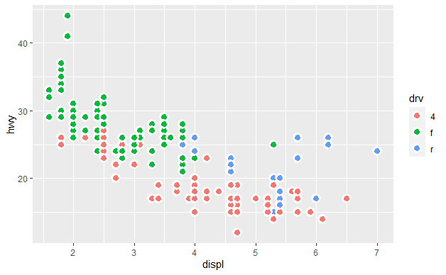

### Section 3.7: Statistical transformations.

**Skip this section.** We may return to it later.

### Section 3.8 Position adjustments

This code chunk show a bar chart with the color aesthetic

```r
ggplot(data = diamonds) +
  geom_bar(mapping = aes(x = cut, colour = cut))
```

This code chunk shows a bar graph with the fill aesthetic.

```r
ggplot(data = diamonds) +
  geom_bar(mapping = aes(x = cut, fill = cut))
```

This shows the bar graph with the fill as clarity rather than cut.

```r
ggplot(data = diamonds) +
  geom_bar(mapping = aes(x = cut, fill = clarity))
```

This code chun shows the bar graph with the position of identity.

```r
ggplot(data = diamonds, mapping = aes(x = cut, fill = clarity)) +
  geom_bar(alpha = 1/5, position = "identity")
```

This code chunk has same graph as above but is transparent to see the overlap.

```r
ggplot(data = diamonds, mapping = aes(x = cut, colour = clarity)) +
  geom_bar(fill = NA, position = "identity")
```

This code block has the graph with the position fill.

```r
ggplot(data = diamonds) +
  geom_bar(mapping = aes(x = cut, fill = clarity), position = "fill")
```

This code block has the bar graph with the position dodge applied.

```r
ggplot(data = diamonds) +
  geom_bar(mapping = aes(x = cut, fill = clarity), position = "dodge")
```

This code block shows a position called jitter that is not useful for bar graphs but is useful for scatterplots.

```r
ggplot(data = mpg) +
  geom_point(mapping = aes(x = displ, y = hwy), position = "jitter")
```

#### Section 3.8 Questions

**1:** What is the problem with this plot? How could you improve it. *Hint:* Remember the size of the `mpg` data set from earlier in this exercise. Does the number of points seem correct? **Note:** Write the code to improve it.

This does not show all the data points. This code block shows how you can fix it.

```r
ggplot(data = mpg) +
  geom_point(mapping = aes(x = cty, y = hwy), position = 'jitter')
```

**2:** What parameters to `geom_jitter()` control the amount of jittering?

width and height control the amount of jitter.

**3:** Compare and contracts `geom_jitter()` with `geom_count()`.

‘geom_jitter’ is better for smaller data sets with overplotting caused by discretness ‘geom_count’ is better for discrete data and overplotting in larger data sets. They bothe fix issues of overplotting and discrete data but in different sizes of data. **4:** What is the default position adjustement for `geom_boxplot()`? Create a visualization of the `mpg` dataset that demonstrates it.

The default for geom_boxplot is dodge2. This code chunks shows the default of geom_boxplot.

```r
ggplot(mpg) +
  geom_boxplot(mapping = aes(x = displ, y = hwy))
```

### Section 3.9: Coordinate systems

**Note:** Read about and do only the code chunk associated with `coord_flip()`. `coord_flip()` is a great layer to use when you have categorical data with longish names as it makes the text easier to read.

This code chunk shows the graph before use of ‘coord_flip’

```r
ggplot(data = mpg, mapping = aes(x = class, y = hwy)) +
  geom_boxplot()
```

This shows the same graph but with ‘coord_flip’

```r
ggplot(data = mpg, mapping = aes(x = class, y = hwy)) +
  geom_boxplot() +
  coord_flip()
```

### Section 3.10: The layered grammar of graphics

Just read this section as a contextual review of everything you just learned.